# CC6MM Evolutionary Algorithms - Tarea 3

## Programación Genética

Este tema es el mas corto del curso durando solo 1 clase. La programacion genetica es muy similar a los algoritmos geneticos que vimos las clases pasadas, pero ahora trabajaremos con arboles. Esto significa que podemos crear programas y encontrar el programa que mejor resuelve algun problema.

Comentarios enviarlos a Alexandre Bergel (abergel@dcc.uchile.cl).

Integrantes del grupo:

- Paola Rioseco
- José Sanz
- Guillermo Pinto
- Guillermo Barriga
- Manuel Bórquez

```python
# para operaciones matematicas
import numpy as np
# para crear copias de los arboles
from copy import deepcopy
# random
import random

# esta funcion dice si el argumento es una funcion o no
def is_function(f):
    return hasattr(f, "__call__")

# esto nos permite recorrer una lista de a pedazos
# ejemplo el input es [1,2,3,4,5,6,7,8]
# con n=2 esta funcion nos hara tener
# [(1,2), (3,4), (5,6), (7,8)]
def chunks(iterable, n):
    for i in range(0, len(iterable), n):
        yield iterable[i:i + n]
```

## Árboles

El codigo abajo define una pequeña libreria que permite manipular arboles. Hay funciones para evaluar el arbol, serializarlo, copiarlo y reemplazar el nodo por otro. Con evaluar nos referimos a por ejemplo el arbol (4 + 5), que es un nodo SUMA y 2 TERMINALes, la evaluacion da 9.

```python
class Node:
    def __init__(self, function):
        # nos aseguramos que el nodo recibe una funcion
        assert is_function(function)
        self.operation = function
        # esto nos permite contar cuantos argumentos recibe la funcion
        self.num_arguments = function.__code__.co_argcount
        self.arguments = []

    # funcion para evaluar un nodo (calcular el resultado)
#    def eval(self):
        # es importante chequear que los argumentos que nos dieron
        # coincidan con los argumentos que necesitamos
#        assert len(self.arguments) == self.num_arguments
        # evaluamos los argumentos, y luego los pasamos como argumentos a
        # la operacion
        # NOTA: esto -> *[...] significa que separa los elementos de la lista
        # ejemplo si tenemos `lista = [1,2,3]`
        # print(lista) -> [1,2,3]
        # print(*lista) -> 1 2 3
        # esto se llama `unpacking`.
        # lo necesitamos porque nuestra funcion recibe N argumentos
        # no una lista de tamaño N.
#        return self.operation(*[node.eval() for node in self.arguments])

    # =======================
    # Evaluación con contexto
    # ======================
    def eval(self, context=None):
        assert len(self.arguments) == self.num_arguments
        # Propaga el contexto hacia los hijos
        return self.operation(*[node.eval(context) for node in self.arguments])

    # hace una lista con todos los hijos
    def serialize(self):
        l = [self]
        for node in self.arguments:
            l.extend(node.serialize())
        return l

    # copia al nodo
    def copy(self):
        return deepcopy(self)

    # reemplaza el nodo por otro
    def replace(self, otherNode):
        # aqui estamos haciendo algo medio hacky.
        # la forma correcta seria tener una referencia al nodo padre y
        # reemplazarse a si mismo por otro.
        # por temas de mantener el codigo corto lo hacemos asi
        # pero no lo hagan en casa!
        assert isinstance(otherNode, Node)
        self.__class__ = otherNode.__class__
        self.__dict__ = otherNode.__dict__


# esta clase representa todos los nodos quetienen 2 argumentos
class BinaryNode(Node):
    num_args = 2
    def __init__(self, function, left, right):
        # revisamos que todo sea un nodo y agregamos a las lista de
        # argumentos
        assert isinstance(left, Node)
        assert isinstance(right, Node)
        super(BinaryNode, self).__init__(function)
        self.arguments.append(left)
        self.arguments.append(right)


class AddNode(BinaryNode):
    def __init__(self, left, right):
        def _add(x,y):
            return x + y
        super(AddNode, self).__init__(_add, left, right)

    # esta es la funcion que define como se mostrara el nodo
    # como es un nodo que REPResenta la suma, lo mostramos como suma
    def __repr__(self):
        return "({} + {})".format(*self.arguments)


class SubNode(BinaryNode):
    def __init__(self, left, right):
        def _sub(x,y):
            return x - y
        super(SubNode, self).__init__(_sub, left, right)

    def __repr__(self):
        return "({} - {})".format(*self.arguments)


class MaxNode(BinaryNode):
    def __init__(self, left, right):
        def _max(x,y):
            return max(x,y)
        super(MaxNode, self).__init__(_max, left, right)

    def __repr__(self):
        return "max({{{}, {}}})".format(*self.arguments)

class MultNode(BinaryNode):
    def __init__(self, left, right):
        def _mult(x,y):
            return x * y
        super(MultNode, self).__init__(_mult, left, right)

    def __repr__(self):
        return "({} * {})".format(*self.arguments)


class TerminalNode(Node):
    # Este nodo representa una hoja de arbol. Es el nodo terminal
    # por lo que no tiene argumentos
    num_args = 0
    def __init__(self, value):
        # igual tenemos que representarlo como una funcion, por como
        # diseñamos el programa. Pero aqui va a ser una funcion vacia
        def _nothind(): pass
        super(TerminalNode, self).__init__(_nothind)
        self.value = value

    def __repr__(self):
        return str(self.value)

#    def eval(self):
        # la evaluacion de un nodo terminal es el valor que contiene
#        return self.value
    # =======================
    # Evaluación con contexto
    # =======================
    def eval(self, context=None):
        return self.value


# ==================
# Ejercicio División
# ==================
class DivNode(BinaryNode):
    def __init__(self, left, right):
        def _div(x, y):
            # División protegida: evita división por 0 o casi 0
            if abs(y) < 1e-6:
                return x
            return x / y
        super(DivNode, self).__init__(_div, left, right)

    def __repr__(self):
        return "({} / {})".format(*self.arguments)

# ===================
# Manejo de Variables
# ===================
class VariableNode(Node):
    num_args = 0

    def __init__(self, name):
        def _nothing():
            pass
        super(VariableNode, self).__init__(_nothing)
        self.name = name  # ej: "x"

    def __repr__(self):
        return self.name

    def eval(self, context=None):
        if context is None or self.name not in context:
            raise ValueError(f"Valor para variable '{self.name}' no definido")
        return context[self.name]

# Clase para el nodo de potencia (x^2)
class PowerNode(BinaryNode):
    def __init__(self, left, right):
        def _pow(x,y):
            return x ** y
        super(PowerNode, self).__init__(_pow, left, right)

    def __repr__(self):
        return "({}^{})".format(*self.arguments)
```

### Funciones

```python
# graficos
import matplotlib.pyplot as plt
import pandas as pd
import sys
sys.setrecursionlimit(5000)
```

```python
#Funcion para medir profundidad
def obtener_profundidad_arbol(node):
    if isinstance(node, TerminalNode):
        return 0
    return 1 + max(obtener_profundidad_arbol(child) for child in node.arguments)

# a partir de un nodo raiz, grafica el arbol completo con matplotlib
def graficar_arbol(raiz, text_dx=0.12, text_dy=0.0, titulo: str = None, color="#4C72B0", imprimir_etiquetas=True, dimensiones=(8, 4)):
    nodes = raiz.serialize()
    pos, edges = {}, []

    def place(n, d=0):
        xs = []
        for ch in n.arguments:
            edges.append((n, ch))
            xs.append(place(ch, d + 1))
        x = sum(xs)/len(xs) if xs else place.next
        if not xs:
            place.next += 1
        pos[n] = (x, -d)
        return x

    place.next = 0
    place(raiz)

    fig, ax = plt.subplots(figsize=dimensiones)
    # aristas
    for p, c in edges:
        x0, y0 = pos[p]; x1, y1 = pos[c]
        ax.plot([x0, x1], [y0, y1], "k-", linewidth=1)

    # nodos y etiquetas al costado
    for n, (x, y) in pos.items():
        ax.scatter(x, y, s=300, color=color)
        if imprimir_etiquetas:
            ax.text(x + text_dx, y + text_dy, str(n), ha="left", va="center", fontsize=9)

    ax.axis("off")
    if titulo:
        plt.title(titulo)
    plt.tight_layout()
    plt.show()

# contar nodos totales y hojas
def contar_nodos(nodo):
    if isinstance(nodo, TerminalNode):
        return 1, 1
    total = 1  # cuenta el nodo actual
    leaves = 0
    for hijo in nodo.arguments:
        c_total, c_leaves = contar_nodos(hijo)
        total += c_total
        leaves += c_leaves
    return total, leaves

def graficar_hotmap(df, value_col, title, cmap="viridis", fmt=".2f", nan_color="lightgray"):
    # pivotea a matriz (rows=pop_size, cols=mutation_rate)
    pivot = df.pivot(index="pop_size", columns="mutation_rate", values=value_col)

    fig, ax = plt.subplots(figsize=(10, 5))
    im = ax.imshow(pivot.values, aspect="auto", interpolation="nearest", cmap=cmap)

    ax.set_title(title)
    ax.set_xlabel("mutation_rate")
    ax.set_ylabel("pop_size")

    ax.set_xticks(np.arange(len(pivot.columns)))
    ax.set_xticklabels([str(c) for c in pivot.columns])
    ax.set_yticks(np.arange(len(pivot.index)))
    ax.set_yticklabels([str(i) for i in pivot.index])

    # anotar valores
    for i in range(pivot.shape[0]):
        for j in range(pivot.shape[1]):
            val = pivot.values[i, j]
            if np.isnan(val):
                continue
            ax.text(j, i, format(val, fmt), ha="center", va="center", fontsize=8)

    plt.colorbar(im, ax=ax)
    plt.tight_layout()
    return fig, ax, pivot
```

El codigo siguiente permite definir un arbol programaticamente, es decir, a mano pero en el computador:

```python
# define la expression: 5 - 3
expr = SubNode(TerminalNode(5), TerminalNode(3))
print(expr)
```

```
(5 - 3)
```

```python
# Se puede evaluar un arbol a mandar un mensaje "eval()" a este
expr.eval()
```

```
2
```

### Ejercicio 1: Representación de Árbol Binario

**P1 - EJERCICIO**: Define programaticamente un arbol que representa la expression: `max({(5 + 6), (2 - 3)})`

```python
#                _           _
#     /\        | |         | |
#    /  \   _ __| |__   ___ | |
#   / /\ \ | '__| '_ \ / _ \| |
#  / ____ \| |  | |_) | (_) | |
# /_/    \_\_|  |_.__/ \___/|_|
#
# WRITE YOUR ANSWER HERE

# Hojas
# Nodos terminales (hojas)
n5 = TerminalNode(5)
n6 = TerminalNode(6)
n2 = TerminalNode(2)
n3 = TerminalNode(3)

# Nodos internos
p1_suma = AddNode(n5, n6)
p1_resta = SubNode(n2, n3)

# Nodo raíz
p1_arbol = MaxNode(p1_suma, p1_resta)
print(p1_arbol)
```

```
max({(5 + 6), (2 - 3)})
```

#### Respuestas:

- Se crearon 4 notos hojas `TerminalNode` para representar los valores numéricos y 2 nodos intermedios para representar la operación de suma `AddNode()` y resta `SubNode()`.
- Al integrar estas representaciones con un nodo raiz por medio de la representación de función **máximo()** `MaxNode()` se completa el árbo **binario**.
- Al mostrar el árbol se observa la **expresión** esperada: `max({(5 + 6), (2 - 3)})`

Verifica que evaluar este arbol retorna `11`

```
[max({(5 + 6), (2 - 3)}), (5 + 6), 5, 6, (2 - 3), 2, 3]
```

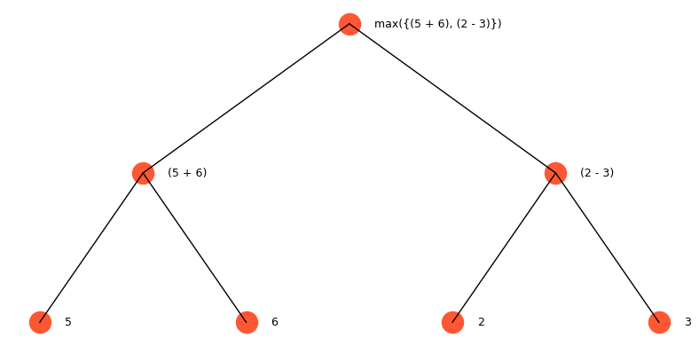

```python
#  ______          _                  _   __                        _           _
# |  ____|        | |                (_) /_/             /\        | |         | |
# | |____   ____ _| |_   _  __ _  ___ _  ___  _ __      /  \   _ __| |__   ___ | |
# |  __\ \ / / _` | | | | |/ _` |/ __| |/ _ \| '_ \    / /\ \ | '__| '_ \ / _ \| |
# | |___\ V / (_| | | |_| | (_| | (__| | (_) | | | |  / ____ \| |  | |_) | (_) | |
# |______\_/ \__,_|_|\__,_|\__,_|\___|_|\___/|_| |_| /_/    \_\_|  |_.__/ \___/|_|
#
# WRITE YOUR ANSWER HERE

# se verifica que el arbol este bien construido
print(p1_arbol.serialize())
graficar_arbol(p1_arbol, color="#FF5733")
```

```python
p1_resultado = p1_arbol.eval()
print(p1_resultado)
```

```
11
```

#### Respuestas:

- Se implementó frunción utilitaria para representar gráficamente lo que hace `Node.serialize()` y se observa que las expresiones están bien definidas. Se observa además:
  - *nodos terminales* corresponden a valores -> hojas
  - *nodos no terminales* corresponden a funciones -> sub-nodos
- Al evaluar el arbol con `Node.eval()` se obtiene el valor esperado **11**, que es el resultado de la expresión `max({(5 + 6), (2 - 3)})`.

## AST - programas y generador

A continuacion presentamos la clase `AST`, permite definir un arbol aleatorio dada un conjunto de funciones permitidas, un conjunto de terminales y una profundidad maxima.

En nuestro ejemplo este arbol puede generar arboles que representen expresiones matematicas con `+`, `-`, `*` y `max`. Son programas simples. Pero facilmente podemos extenderlo a soportar expresiones condicionales como `if`, y ciclos como `for` y `while`. Es decir, podemos generar programas completos de forma aleatoria.

```python
# un AST es un arbol que representa un programa, la idea aqui es tener
# un generador, que pueda generar ASTs aleatorios
class AST:
    def __init__(self, allowed_functions, allowed_terminals, prob_terminal=0.3):
        # las funciones (nodos en nuestro caso) que nuestro programa puede tener
        self.functions = allowed_functions
        # los terminales admitidos en nuestro programa. Numeros por ejemplo
        self.terminals = allowed_terminals
        # para no tener un arbol infinitamente profundo, existe una posibilidad
        # de que, a pesar de que ahora toque hacer otro sub arbol, que se ignore
        # eso y se ponga un terminal en su lugar.
        self.prob = prob_terminal

    # esta funcion ya la hemos visto, nos permite llamar al AST como si fuera
    # una funcion. max_depth es la produndidad que queremos tenga el arbol
    def __call__(self, max_depth=10):
        # aqui tenemos una funcion auxiliar. Nos permitira hacer esto recursivo
        def create_rec_tree(depth):
            # si `depth` es mayor a 0, nos toca crear un sub-arbol
            if depth > 0:
                # elegimos una funcion aleatoriamente
                node_cls = random.choice(self.functions)
                # aqui iremos dejando los argumentos que necesita la funcion
                arguments = []
                # para cada argumento que la funcion necesite...
                for _ in range(node_cls.num_args):
                    # existe un `prob` probabilidad de que no sigamos creando
                    # sub-arboles y lleguemos y cortemos aqui para hacer
                    # un nodo terminal
                    if random.random() < self.prob:
                        arguments.append(create_rec_tree(0))
                    else:
                        # la otra es seguir creando sub-arboles recursivamente
                        arguments.append(create_rec_tree(depth - 1))

                # `arguments` es una lista y los nodos necesitan argumentos
                # asi que hacemos "unpacking" de la lista
                return node_cls(*arguments)
            else:
                # si `depth` es 0 entonces creamos un nodo terminal con
                # alguno de los terminales permitidos que definimos inicialmente
                # ================================
                # Permitir terminales no numéricos
                # ================================
#                return TerminalNode(random.choice(self.terminals))
                t = random.choice(self.terminals)

                if isinstance(t, Node):
                    return t.copy()          # para no reutilizar el mismo objeto
                return TerminalNode(t)


        # llamamos a la funcion auxiliar para crear un arbol de profundidad `max_depth`
        return create_rec_tree(max_depth)
```

La clase `AST` permite definir un generador de arboles. Para definir este generador, se requiere un conjunto de funciones (nodos no terminales), un conjunto de valores (nodos terminales). Adicionalmente agregamos un argumento que permite saltarse la restriccion de profundidad del arbol. Es decir, si le decimos al generador que cree un arbol de produndidad 10, tendremos muchisimos nodos y funciones y nuestro arbol crecera demasiado. Para mitigar un poco esto, tenemos el argumento `prob_terminal`, que dada una probabilidad, ignora que le falten sub-arboles por generar y directamente retorna un terminal. Asi termina la generacion de sub-arboles por ese lado.

```python
generator = AST([AddNode, SubNode, MaxNode, MultNode], list(range(10)), prob_terminal=0.4)
```

```python
# genera un arbol de profundidad 2
tree1 = generator(2)
tree1
```

```
((1 - 5) * (7 + 8))
```

```python
# "Serializar" permite obtener una lista de _todos_ los nodos que componen un arbol
print(tree1.serialize())
```

```
[((1 - 5) * (7 + 8)), (1 - 5), 1, 5, (7 + 8), 7, 8]
```

### Ejercicio 2: Generador de Árboles

**P2 - EJERCICIO**: Construye un generador de arboles con una profondidad maxima de 10 y verifica que un valor `prob_terminal` alto permite generar arboles con menor profundidad.

```python
#  _____            __                  _ _     _           _
# |  __ \          / _|                | (_)   | |         | |
# | |__) | __ ___ | |_ _   _  _ __   __| |_  __| | __ _  __| |
# |  ___/ '__/ _ \|  _| | | || '_ \ / _` | |/ _` |/ _` |/ _` |
# | |   | | | (_) | | | |_| || | | | (_| | | (_| | (_| | (_| |
# |_|   |_|  \___/|_|  \__,_||_| |_|\__,_|_|\__,_|\__,_|\__,_|
#
# WRITE YOUR ANSWER HERE
```

#### Profundidad con `prob_terminal` Alta

```python
print("[INFO] Arbol generado con probabilidad terminal alta:")
p2_a_profundidad_maxima = 10
p2_a_probability_terminal = 0.39

p2_a_generator = AST(
    [AddNode, SubNode, MaxNode, MultNode],
    list(range(p2_a_profundidad_maxima)),
    prob_terminal=p2_a_probability_terminal
)

# profundidad maxima 10
p2_a_tree = p2_a_generator(p2_a_profundidad_maxima)
p2_a_profundidad = obtener_profundidad_arbol(p2_a_tree)
total, hojas = contar_nodos(p2_a_tree)
internos = total - hojas

print(f" - profundidad del arbol generado: {p2_a_profundidad}")
print(f" - total nodos: {total} (internos: {internos}, hojas: {hojas})")
print(f" - probabilidad terminal: {p2_a_probability_terminal}")
```

```
[INFO] Arbol generado con probabilidad terminal alta:
 - profundidad del arbol generado: 3
 - total nodos: 7 (internos: 3, hojas: 4)
 - probabilidad terminal: 0.39
```

```python
print("[INFO] serialize: nodos en el arbol generado:")
print(p2_a_tree.serialize())
```

```
[INFO] serialize: nodos en el arbol generado:
[(max({5, (5 - 9)}) + 4), max({5, (5 - 9)}), 5, (5 - 9), 5, 9, 4]
```

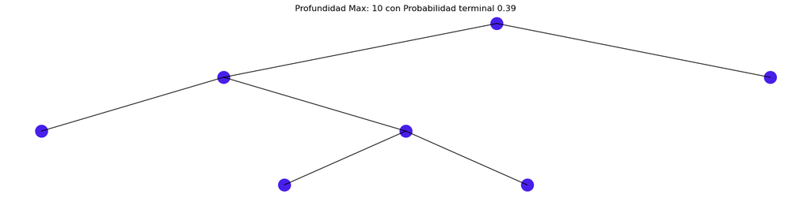

```python
graficar_arbol(
    p2_a_tree,
    titulo=f"Profundidad Max: {p2_a_profundidad_maxima} con Probabilidad terminal {p2_a_probability_terminal}",
    color="#481FEA",
    imprimir_etiquetas=False,
    dimensiones=(16, 4)
)
```

#### Profundidad con `prob_terminal` Baja

```python
print("[INFO] Arbol generado con probabilidad terminal baja:")
p2_b_profundidad_maxima = 10
p2_b_probability_terminal = 0.19

p2_b_generator = AST(
    [AddNode, SubNode, MaxNode, MultNode],
    list(range(p2_b_profundidad_maxima)),
    prob_terminal=p2_b_probability_terminal
)

# profundidad maxima 10
p2_b_tree = p2_b_generator(p2_b_profundidad_maxima)
p2_b_profundidad = obtener_profundidad_arbol(p2_b_tree)
total, hojas = contar_nodos(p2_b_tree)
internos = total - hojas

print(f" - profundidad del arbol generado: {p2_b_profundidad}")
print(f" - total nodos: {total} (internos: {internos}, hojas: {hojas})")
print(f" - probabilidad terminal: {p2_b_probability_terminal}")
```

```
[INFO] Arbol generado con probabilidad terminal baja:
 - profundidad del arbol generado: 10
 - total nodos: 195 (internos: 97, hojas: 98)
 - probabilidad terminal: 0.19
```

```python
print("[INFO] serialize: nodos en el arbol generado:")
print(p2_b_tree.serialize())
```

```
[INFO] serialize: nodos en el arbol generado:
[(6 * (9 - (((max({6, max({(((5 * 2) * 2) * max({max({1, 8}), max({5, 0})})), (((8 - 5) - (7 + 8)) * ((4 * 5) * (8 + 4)))})}) * 8) - (max({((((9 - 9) * max({6, 9})) - ((0 * 3) - max({6, 1}))) - (6 * max({(4 + 9), (7 - 1)}))), (8 - (max({(9 * 7), (5 + 5)}) * (max({0, 0}) - (1 - 8))))}) + (max({max({(…
```

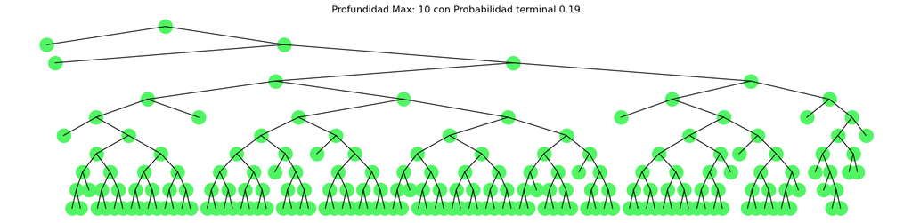

```python
graficar_arbol(
    p2_b_tree,
    titulo=f"Profundidad Max: {p2_b_profundidad_maxima} con Probabilidad terminal {p2_b_probability_terminal}",
    color="#51F564",
    imprimir_etiquetas=False,
    dimensiones=(16, 4)
)
```

#### Profundidad con `prob_terminal` vs `max_depth`

Para controlar tamaño, se deben ajustar ambos parámetros: reducir max_depth o subir prob_terminal si se buscan árboles cortos.

```python
print("[INFO] Arbol generado con equilibrio entre probabilidad terminal y máximo de profundidad:")
p2_c_profundidad_maxima = 6
p2_c_probability_terminal = 0.42

p2_c_generator = AST(
    [AddNode, SubNode, MaxNode, MultNode],
    list(range(p2_c_profundidad_maxima)),
    prob_terminal=p2_c_probability_terminal
)

p2_c_tree = p2_c_generator(p2_c_profundidad_maxima)
p2_c_profundidad = obtener_profundidad_arbol(p2_c_tree)
total, hojas = contar_nodos(p2_c_tree)
internos = total - hojas

print(f" - profundidad del arbol generado: {p2_c_profundidad}")
print(f" - total nodos: {total} (internos: {internos}, hojas: {hojas})")
print(f" - probabilidad terminal: {p2_c_probability_terminal}")
```

```
[INFO] Arbol generado con equilibrio entre probabilidad terminal y máximo de profundidad:
 - profundidad del arbol generado: 6
 - total nodos: 25 (internos: 12, hojas: 13)
 - probabilidad terminal: 0.42
```

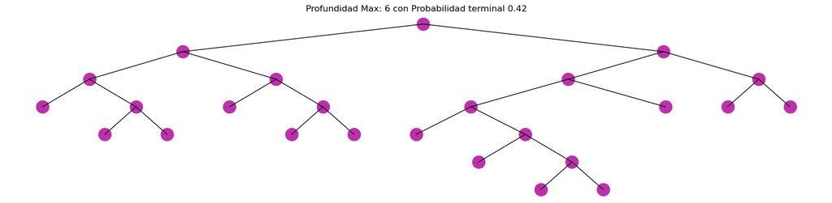

```python
graficar_arbol(
    p2_c_tree,
    titulo=f"Profundidad Max: {p2_c_profundidad_maxima} con Probabilidad terminal {p2_c_probability_terminal}",
    color="#BC30AC",
    imprimir_etiquetas=False,
    dimensiones=(16, 4)
)
```

#### Respuestas

**Ajustes Parámetro `prob_terminal`**:

- Esto valida la intención de prob_terminal: es un “freno probabilístico” a la expansión.
  - si la probabilidad es baja, el generador sigue creando subárboles hasta agotar la profundidad
  - si es alta, aparecen más hojas antes de llegar al límite.

Aun así, max_depth es un parámetro relevante respecto a la probabilidad terminal: con un tope alto, incluso con prob_terminal elevada se puede alcanzar profundidad máxima.

**Ajustes Parámetros `prob_terminal` vs `max_depth`**:

## Algoritmo de Programación Genética (GP)

La clase `GP` define el algoritmo completo. Es muy similar a `GA` que hemos visto, pero las operaciones geneticas cambiaron.

```python
IMPRIMIR = True
```

```python
class GP:
    def __init__(self, function_set, terminal_set, fitness, pop_size=500, depth=3, crossover_rate=0.5,
                 mutation_rate=0.01, iterations=50, min_fitness=None, tournament_sampling=20):
        self.generator = AST(function_set, terminal_set)
        self.fitness_function = fitness
        self.population_size = pop_size
        # la probabilidad de hacer crossover entre 2 individuos
        self.crossover_rate = crossover_rate
        self.mutation_rate = mutation_rate
        self.max_iterations = iterations
        if min_fitness is None:
            self.min_fitness = float("inf")
        else:
            self.min_fitness = min_fitness
        # cuantos invididuos random se seleccionan por torneo
        self.tournament_sampling = tournament_sampling
        # la profundidad de los arboles
        self.depth = depth

    def run(self):
        iters = 0
        best_fitness_list = []
        avg_list = []
        # creamos la poblacion
        population = self.generate_population()
        # evaluamos la poblacion
        fitness = self.get_fitness(population)
        # el mejor individuo sera una tupla (individuo, fitness)
        best_individual = (population[np.argmax(fitness)], max(fitness))

        # mientras no hayamos terminado las iteraciones Y nuestro mejor
        # individuo sea menor que una cota que pongamos -> seguimos
        while iters < self.max_iterations and best_individual[1] < self.min_fitness:
            if IMPRIMIR:
                print(f"iteration {iters} of {self.max_iterations}")

            # agregamos el fitness del mejor individuo
            best_fitness_list.append(best_individual[1])
            # y metemos el promedio a la lista de los promedios
            avg_list.append(np.mean(fitness))

            if IMPRIMIR:
                print(f"best is: {best_individual[0]}\nwith fitness {best_individual[1]}")
                print("-" * 20)

            # hacemos la seleccion basandonos en los fitness de la poblacion
            parents = self.select(population, fitness)
            # creamos una nueva poblacion
            population = self.create_new_population(parents)
            # calculamos el nuevo fitness para esta poblacion
            fitness = self.get_fitness(population)
            # hacemos de nuevo al mejor individuo
            best_individual = (population[np.argmax(fitness)], max(fitness))

            iters += 1

        if IMPRIMIR:
            print(f"iteration {iters} of {self.max_iterations}")

        best_fitness_list.append(max(fitness))
        avg_list.append(np.mean(fitness))

        if IMPRIMIR:
            print(f"best is: {best_individual[0]}\nwith fitness {best_individual[1]}")
            print("-" * 20)

        return best_fitness_list, avg_list, best_individual[0]

    # creamos la nueva poblacion
    def generate_population(self):
        population = []
        for _ in range(self.population_size):
            # generamos un nuevo arbol de profundidad `depth` aleatorio
            population.append(self.generator(self.depth))
        return population

    # calculamos el fitness de cada individuo
    def get_fitness(self, population):
        fitness = []
        for p in population:
            # fitness de cada individuo
            fitness.append(self.fitness_function(p))
        return fitness

    # seleccionamos a los padres
    def select(self, population, pop_fitness):
        parents = []
        # tenemos que hacer 2N torneos para una poblacion de N elementos
        for _ in range(2 * self.population_size):
            # elejimos `tournament_sampling` elementos aleatorios
            competitors_idx = np.random.choice(len(population), self.tournament_sampling)
            # hacemos un mapeo de (individuo, fitness individuo)
            competitors = [(population[idx], pop_fitness[idx]) for idx in competitors_idx]

            # elegimos al mejor de esos aleatorios que elegimos
            # como creamos llegan (individuo, fitness individuo)
            # la eleccion ocurre basandonos en el fitness (seleccionamos [1])
            winner = max(competitors, key=lambda x: x[1])
            # el individuo esta en [0]
            parents.append(winner[0])
        return parents

    # usando los padres, creamos nueva poblacion
    def create_new_population(self, parents):
        new_population = []
        # usamos la funcion `chunks` para recorrer de a 2 elementos
        for p1, p2 in chunks(parents, 2):
            # creamos un nuevo elemento
            new_population.append(self.create_new_element(p1, p2))
        return new_population

    # crea un nuevo elemento basandonos en los 2 padres
    def create_new_element(self, p1, p2):
        # primero hay que decidir si hay crossover o no
        rand = random.random()
        # generalmente es bien probable que lo hagamos
        # pero existe la probabilidad de que no
        if rand <= self.crossover_rate:
            # hacemos una copia del padre 1
            new_element = p1.copy()
            # elegimos un punto del padre 1 a cortar aleatoriamente
            point_parent_1 = random.choice(new_element.serialize())
            # elegimos un punto en el padre 2 a cortar, tambien aleatoriamente
            # y creamos una copia de ese subarbol
            point_parent_2 = random.choice(p2.serialize()).copy()
            # reemplzamos el punto del padre 1 que seleccionamos, con
            # el punto que elegimos del padre 2
            point_parent_1.replace(point_parent_2)
        else:
            # si no hacemos crossover, entonces elegimos al mejor de los 2
            # padres. Necesitamos la copia.
            if self.fitness_function(p1) >= self.fitness_function(p2):
                new_element = p1.copy()
            else:
                new_element = p2.copy()

        # aqui hacemos la putacion
        rand = random.random()
        if rand <= self.mutation_rate:
            # si toca hacer mutacion, creamos un nuevo arbol
            # de profundidad aleatoria entre 0 y `depth.
            depth = random.randint(0, self.depth)
            # reemplazamos el arbol que recien creamos en algun punto aleatorio
            # del nuevo individuo que sacamos del crossover.
            random.choice(new_element.serialize()).replace(self.generator(depth))

        return new_element
```

### Algoritmo en accion

El codigo siguiente usa `GP` para buscar una expression que se acerca al valor `target_number`. El desafio es que dado un conjunto de numeros, como podemos operarlos tal que la evaluacion del arbol resultate de un numero muy cercano a `target_number`.

```python
# busquemos este numero
target_number = 46436

# el 0 es el mejor! Todo lo demas es negativo.

def fitness_fn(element):
    # esta fitness evalua el elemento sacando que tan lejos
    # esta del numero que queremos llegar
    generated = element.eval()
    # como queremos maximizar, es negativo
    return -abs(target_number - generated)

def length_fitness_fn(element):
    # esta hace lo mismo que antes, pero pone una penalizacion
    # cuando el tamaño del arbol es muy grande
    return fitness_fn(element) - len(element.serialize())

# va cambiando el fitness cuando se queda pegado por muchas iteraciones
# cambia fitness entre
# -> encuentra lo mejor que puedas, aumentar el tamaño con `fitness_fn`
# -> reduce el tamaño con `length_fitness_fn` pero intenta mantener el fitness
class MetaFitness():
    def __init__(self, patience=200, fitness_switch=50):
        self.best = float("inf")
        # cuanto estamos dispuestos a esperar
        self.patience = patience
        # si llegamos a este valor, cambiamos de fitness
        self.fitness_switch = fitness_switch

        # cuantas veces llevamos sin vambios
        self.current_wait = 0
        # vamos a ir variando esta
        self.current_f = fitness_fn

        # variables auxiliares para que nos de el estado
        # esta significa que usaremos `fitness_fn`
        self.use_standard = True
        # esta significa que aun no hemos roto la paciencia
        self.fast_approx = True

    def __call__(self, element):
        # si aun no rompemos la paciencia pero encontramos un individuo bueno
        if self.fast_approx and self.best > self.fitness_switch:
            # cambiamos a minimizar el tamaño del arbol
            self.current_f = length_fitness_fn
            self.use_standard = False
            self.fast_approx = False

        # si ya rompimos la paciencia
        if self.current_wait >= self.patience:
            print("Changing fitness")
            # cambiamos de fitness
            self.use_standard = not self.use_standard
            # reiniciamos la paciencia
            self.current_wait = 0

        # si ya rompimos la paciencia, vamos variando entre las 2 fitness
        if not self.fast_approx:
            # vamos variando entre ambas cada vez que rompamos la paciencia
            if self.use_standard:
                self.current_f = fitness_fn
            else:
                self.current_f = length_fitness_fn

        # vamos guardando el mejor fitness. Si es el mejor dejamos de esperar
        # y lo guardamos.
        # si no es mejor que el que teniamos guardado, agregamos 1
        # a la espera
        e_fitness = self.current_f(element)
        if e_fitness > self.best:
            self.best = e_fitness
            self.current_wait = 0
        else:
            self.current_wait += 1

        return e_fitness
```

Ejecuta el siguiente codigo y ve como le va al algoritmo con la funcion de fitness que solo considera que tan cerca esta de al solucion. Funciona? Que tal si usas las otras fitness?

```python
_pop_size = 1000
_iterations = 200
ga = GP(function_set=[AddNode, SubNode, MaxNode, MultNode],
        terminal_set=[5,76,8,32,6,26,5],
        fitness=fitness_fn,
        #fitness=length_fitness_fn,
        #fitness=MetaFitness(patience=_pop_size*10),
        pop_size=_pop_size,
        depth=5,
        crossover_rate=0.9,
        mutation_rate=0.1,
        iterations=_iterations,
        min_fitness=0,
        tournament_sampling=_pop_size//10)

best_fitness_list, avg_list, best_individual = ga.run()
```

```python
print(best_individual)
print(f"Tree length: {len(best_individual.serialize())}")
print(f"best individual: {best_individual.eval()} vs {target_number}")
```

```
(((((8 - 26) - (32 + 26)) + (((26 + 5) + 26) * (26 + 6))) - (((6 + 32) * (5 - 6)) - max({(8 - 32), (6 - 6)}))) * 26)
Tree length: 35
best individual: 46436 vs 46436
```

## Ejercicios

### Ejercicio 3: Algoritmo de Programación Genética (GP)

**P3 - EJERCICIO**: Usando `GP` encuentra una expresion que se acerque al numero `459`, usando solo `suma`, `resta` y `maximo` con los valores 25, 7, 8, 100, 4 y 2.

```python
#  _  _   _____ ___
# | || | | ____/ _ \
# | || |_| |__| (_) |
# |__   _|___ \\__, |
#    | |  ___) | / /
#    |_| |____/ /_/
#
# WRITE YOUR ANSWER HERE

target_number = 459
print(f"[INFO] GP para encontrar target_number: {target_number}")
_pop_size = 1000
_iterations = 200

p3_ga = GP(function_set=[AddNode, SubNode, MaxNode],
        terminal_set=[25, 7, 8, 100, 4, 2],
        fitness=fitness_fn,
        #fitness=length_fitness_fn,
        #fitness=MetaFitness(patience=_pop_size*10),
        pop_size=_pop_size,
        depth=5,
        crossover_rate=0.9,
        mutation_rate=0.1,
        iterations=_iterations,
        min_fitness=0,
        tournament_sampling=_pop_size//10)

p3_best_fitness_list, p3_avg_list, p3_best_individual = p3_ga.run()

print()
print(f"[INFO] Resultado para target_number: {target_number}")
print(f" - Mejor individuo encontrado: {p3_best_individual}")
print(f" - Evaluación Mejor Valor encontrado: {p3_best_individual.eval()}")
print(f" - Error absoluto: {abs(target_number - p3_best_individual.eval())}")
print(f" - Largo: {len(p3_best_individual.serialize())}")
print(f" - Serialización: {p3_best_individual.serialize()}")
```

```
[INFO] GP para encontrar target_number: 459

[INFO] Resultado para target_number: 459
 - Mejor individuo encontrado: ((100 + (((100 - 4) + (7 + 25)) + (max({100, 2}) + 100))) + (4 + (2 + 25)))
 - Evaluación Mejor Valor encontrado: 459
 - Error absoluto: 0
 - Largo: 21
 - Serialización: [((100 + (((100 - 4) + (7 + 25)) + (max({100, 2}) + 100))) + (4 + (2 + 25))), (100 + (((100 - 4) + (7 + 25)) + (max({100, 2}) + 100))), 100, (((100 - 4) + (7 + 25)) + (max({100, 2}) + 100)), ((100 - 4) + (7 + 25)), (100 - 4), 100, 4, (7 + 25), 7, 25, (max({100, 2}) + 100), max({100…
```

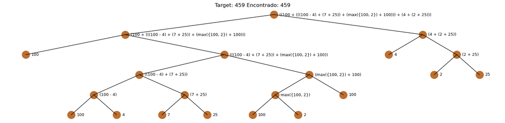

```python
graficar_arbol(
    p3_best_individual,
    titulo=f"Target: {target_number} Encontrado: {p3_best_individual.eval()}",
    color="#BC6F30",
    imprimir_etiquetas=True,
    dimensiones=(16, 4)
)
```

#### Respuestas

**Notas**:

- La implementación respeta el flujo estándar de **Programación Genética (GP)**:
  - inicialización de una población de árboles (expresiones)
  - evaluación mediante una **función fitness**
  - selección (torneo)
  - aplicación de operadores genéticos (crossover/mutación) para generar nuevas soluciones.
- La `fitness_fn` utilizada es adecuada el objetivo numérico de encontrar el valor **459**:
  - maximiza `-abs(target - eval(tree))`, lo que equivale a **minimizar el error absoluto**.
- En particular, el óptimo global es `0`, por lo que fijar `min_fitness=0` como criterio de término es correcto y produce detención inmediata cuando se encuentra una solución exacta.

**Análisis de resultados**:

**Conclusiones**:

- La implementación es correcta y consistente con la teoría de GP: encontró una expresión con `+`, `-`, `max` y terminales `{25, 7, 8, 100, 4, 2}` que evalúa exactamente a **459**, alcanzando el óptimo (fitness 0) en la iteración 1.
- El resultado confirma que, con población grande y presión selectiva alta, GP puede **converger muy rápido** cuando existe una solución accesible en el espacio de expresiones
- Se observa posible evidencia el fenómeno de **bloat**, por lo que una mejora natural sería incorporar parsimonia o control de profundidad para obtener soluciones más compactas e interpretables.

### Ejercicio 4: Hotmap Variación Tasa Mutación y Tamaño de Populación

**P4 - EJERCICIO**: Construye una hotmap con la variación de la tasa de mutacion y el tamaño de la populación. Cual son sus conclusiones?

Ayuda: es lo mismo que hicimos con `GA`.

```python
#  _    _       _
# | |  | |     | |
# | |__| | ___ | |_ _ __ ___   __ _ _ __
# |  __  |/ _ \| __| '_ ` _ \ / _` | '_ \
# | |  | | (_) | |_| | | | | | (_| | |_) |
# |_|  |_|\___/ \__|_| |_| |_|\__,_| .__/
#                                  | |
#                                  |_|
#
# WRITE YOUR ANSWER HERE

target_number = 459

SEED = 42
p4_mutation_rates = [0.0, 0.02, 0.05, 0.1, 0.2]
p4_pop_sizes = [10, 25, 50, 100, 200]

# experimentos pequeños
p4_n_runs = 5
p4_n_iterations = 80
p4_depth = 5
p4_crossover_rate = 0.9

# éxito exacto (si no hay división float)
p4_success_fitness = 0

# torneo menos agresivo para reducir bloat y costo de copia
# (en ejecutar_gc)
tournament_sampling = 10
```

```python
def ejecutar_gc(pop_size,
                mutation_rate,
                n_interactions,
                depth,
                crossover_rate,
                success_fitness,
                seed=None):
    if seed is not None:
        random.seed(seed)
        np.random.seed(seed)

    gp = GP(
        function_set=[AddNode, SubNode, MaxNode],
        terminal_set=[25, 7, 8, 100, 4, 2],
        fitness=fitness_fn,
        pop_size=pop_size,
        depth=depth,
        crossover_rate=crossover_rate,
        mutation_rate=mutation_rate,
        iterations=n_interactions,
        min_fitness=success_fitness,
        tournament_sampling=max(2, int(np.sqrt(pop_size)))
        #tournament_sampling=max(2, pop_size // 10)
    )

    best_fitness_list, avg_list, best_individual = gp.run()

    best_fit = fitness_fn(best_individual)
    best_val = best_individual.eval()
    best_err = abs(target_number - best_val)

    # iteración de éxito: primer índice donde best_fitness_list llega a 0
    # (si nunca llega, queda None)
    hit_iter = None
    for i, f in enumerate(best_fitness_list):
        if f >= success_fitness:  # 0 es el máximo; f==0 cuando exacto
            hit_iter = i
            break

    tree_size = len(best_individual.serialize())

    return {
        "success": (best_fit == success_fitness),
        "hit_iter": hit_iter,
        "final_fitness": best_fit,
        "final_error": best_err,
        "tree_size": tree_size
    }
```

```python
IMPRIMIR = False
resultados = []
experimento_num = 0

for ps in p4_pop_sizes:
    for mr in p4_mutation_rates:
        runs = []
        for r in range(p4_n_runs):
            experimento_num += 1
            out = ejecutar_gc(
                ps,
                mr,
                p4_n_iterations,
                p4_depth,
                p4_crossover_rate,
                p4_success_fitness,
                seed= int(SEED + experimento_num)
            )
            runs.append(out)

        # agregación por celda
        success_rate = np.mean([x["success"] for x in runs])

        hit_iters = [x["hit_iter"] for x in runs if x["hit_iter"] is not None]
        avg_hit_iter = np.mean(hit_iters) if len(hit_iters) > 0 else np.nan

        avg_final_fit  = np.mean([x["final_fitness"] for x in runs])
        avg_tree_size  = np.mean([x["tree_size"] for x in runs])
        avg_final_err  = np.mean([x["final_error"] for x in runs])

        resultados.append({
            "pop_size": ps,
            "mutation_rate": mr,
            "success_rate": success_rate,
            "avg_hit_iter": avg_hit_iter,
            "avg_final_fitness": avg_final_fit,
            "avg_final_error": avg_final_err,
            "avg_tree_size": avg_tree_size
        })

print("[INFO] Resultados del experimento de hiperparámetros:")
print(f" - total experimentos: {experimento_num}")
print(f" - repeticiones por experimento: {p4_n_runs}")
print(f" - total resultados: {len(resultados)}")
```

```
[INFO] Resultados del experimento de hiperparámetros:
 - total experimentos: 125
 - repeticiones por experimento: 5
 - total resultados: 25
```

```python
df_res = pd.DataFrame(resultados)
# df_res.head()
```

#### Heatmap 1: tasa de éxito (más alto = mejor)

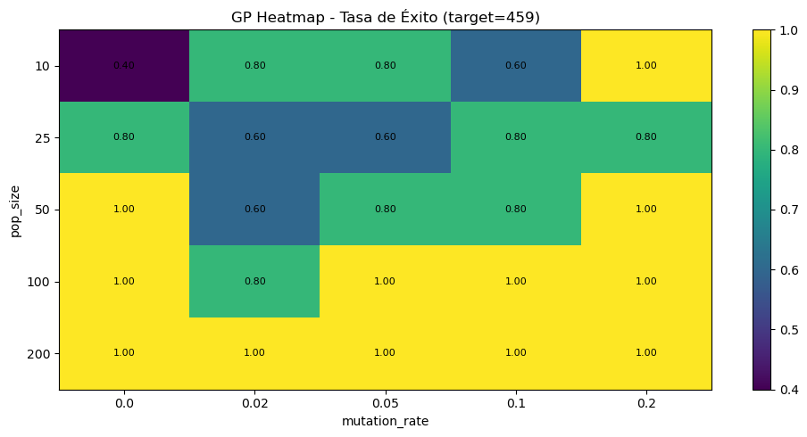

```python
fig1, ax1, p1 = graficar_hotmap(
    df_res, "success_rate",
    title=f"GP Heatmap - Tasa de Éxito (target={target_number})",
    fmt=".2f"
)
plt.show()
```

#### Heatmap 2: iteración promedio al éxito (más bajo = mejor)

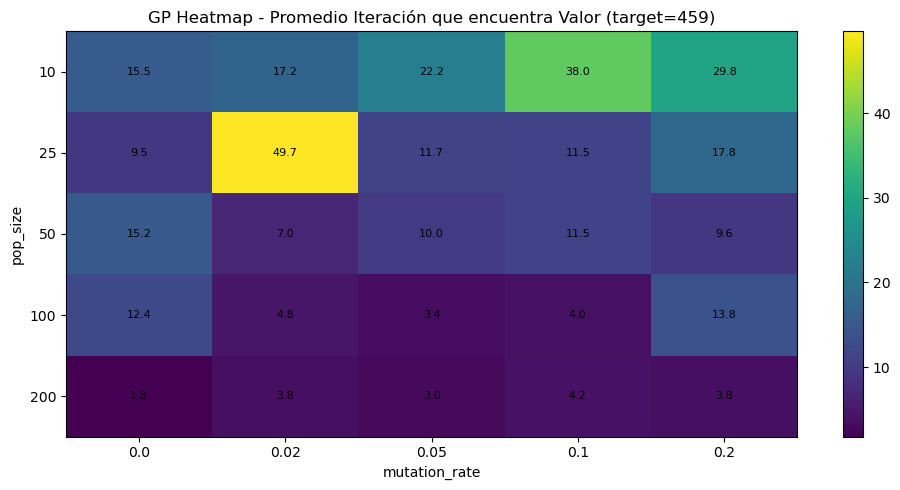

```python
fig2, ax2, p2 = graficar_hotmap(
    df_res, "avg_hit_iter",
    title=f"GP Heatmap - Promedio Iteración que encuentra Valor (target={target_number})",
    fmt=".1f"
)
plt.show()
```

#### Heatmap 3: tamaño promedio del árbol (bloat) (más bajo = mejor)

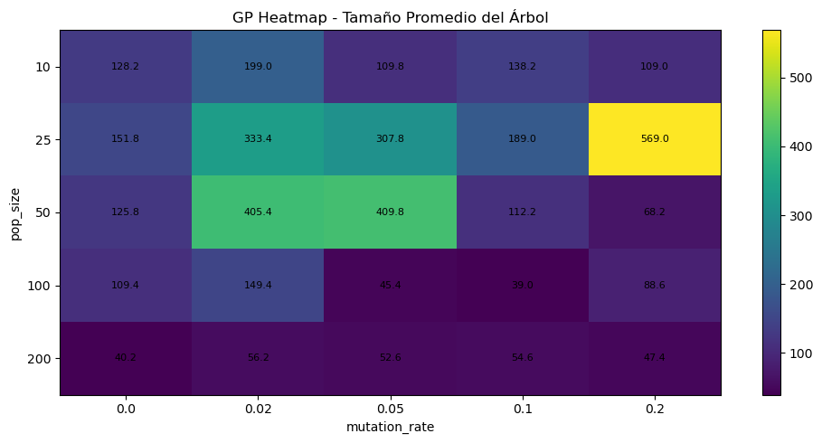

```python
fig3, ax3, p3 = graficar_hotmap(
    df_res, "avg_tree_size",
    title="GP Heatmap - Tamaño Promedio del Árbol",
    fmt=".1f"
)
plt.show()
```

#### Respuestas

**Análisis de resultados**:

**Conclusiones**:

- Los resultados observados son coherentes con la teoría clásica de Programación Genética:
  - El **tamaño de la población** es el principal motor de exploración del espacio de programas.
  - La **mutación** actúa como mecanismo de balance exploración/explotación.
  - El **bloat** emerge naturalmente cuando no existen presiones explícitas por simplicidad.
  - Para problemas simples, GP puede converger extremadamente rápido, incluso en pocas generaciones.
  - El ejercicio demuestra que, para objetivos simples, **no es necesario usar configuraciones grandes ni costosas**.
    - Una calibración adecuada permite obtener resultados correctos, rápidos y estables, validando tanto la implementación como los principios teóricos de la Programación Genética.

**Adicionalmente**:

[figure not shown]

[figure not shown]

```python
plt.figure(figsize=(8, 5))

for ps in sorted(df_res["pop_size"].unique()):
    sub = df_res[df_res["pop_size"] == ps].sort_values("mutation_rate")
    plt.plot(
        sub["mutation_rate"],
        sub["success_rate"],
        marker="o",
        label=f"pop_size={ps}"
    )

plt.xlabel("Tasa de Mutación")
plt.ylabel("Tasa de Éxito")
plt.title(f"GP — Tasa de Éxito vs Tasa de Mutación (target={target_number})")
plt.ylim(-0.05, 1.05)
plt.grid(True, alpha=0.3)
plt.legend(title="Population size")
plt.tight_layout()
plt.show()

plt.figure(figsize=(8, 5))

for mr in sorted(df_res["mutation_rate"].unique()):
    sub = df_res[df_res["mutation_rate"] == mr].sort_values("pop_size")
    plt.plot(
        sub["pop_size"],
        sub["success_rate"],
        marker="o",
        label=f"mutation_rate={mr}"
    )

plt.xlabel("Population size")
plt.ylabel("Success rate")
plt.title(f"GP — Tasa de Éxito vs Tamaño de Población (target={target_number})")
plt.ylim(-0.05, 1.05)
plt.xscale("log")
plt.grid(True, alpha=0.3)
plt.legend(title="Mutation rate")
plt.tight_layout()
plt.show()
```

**notas**

### Ejercicio 5: Nueva Función División

**P5 - EJERCICIO**: Agrega la funcion de division al conjunto de funciones. Esta hay que implementarla arriba donde estan las otras funciones, pero hay un detalle, **cuidado con dividir por 0**!

```python
#  _____  _       _     _
# |  __ \(_)     (_)   (_)
# | |  | |___   ___ ___ _  ___  _ __
# | |  | | \ \ / / / __| |/ _ \| '_ \
# | |__| | |\ V /| \__ \ | (_) | | | |
# |_____/|_| \_/ |_|___/_|\___/|_| |_|
#
# WRITE YOUR ANSWER HERE

p5_n5 = TerminalNode(5)
p5_n6 = TerminalNode(6)
p5_n2 = TerminalNode(2)
p5_n3 = TerminalNode(3)

# Nodos internos
p5_suma = AddNode(p5_n5, p5_n6)
p5_resta = SubNode(p5_n2, p5_n3)

# Nodo raíz
p5_arbol = DivNode(p5_suma, p5_resta)
print(p5_arbol)
```

```
((5 + 6) / (2 - 3))
```

#### Evaluación Función División

```python
print("[INFO] Evaluación del árbol con división:")
p5_resultado = p5_arbol.eval()
print(p5_resultado)
```

```
[INFO] Evaluación del árbol con división:
-11.0
```

#### Gráfico Árbol usando División

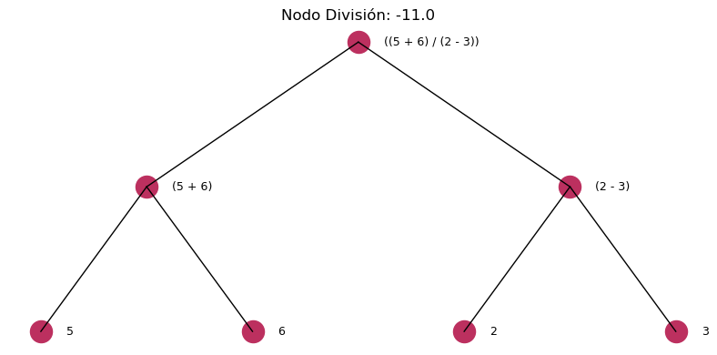

```python
graficar_arbol(
    p5_arbol,
    titulo=f"Nodo División: {p5_arbol.eval()}",
    color="#BC305F",
    imprimir_etiquetas=True,
    dimensiones=(8, 4)
)
```

**notas**:

- Se observa correcto uso de la función división en la clase Nodo
- La expresión matemática (5+6)/(2-3) = -11

#### GP para Encontrar Valor Objetivo usando Función División

```python
target_number = 45
print(f"[INFO] GP para encontrar target_number: {target_number}")

p5_pop_size = 200
p5_iterations = 80
EPS = 1e-6

p5_ga = GP(function_set=[AddNode, SubNode, DivNode],
        terminal_set=[5,76,8,32,6,26,5],
        fitness=fitness_fn,
        pop_size=p5_pop_size,
        depth=4,
        crossover_rate=0.9,
        mutation_rate=0.1,
        iterations=p5_iterations,
        min_fitness=-EPS,
        tournament_sampling=p5_pop_size//10)

p5_best_fitness_list, p5_avg_list, p5_best_individual = p5_ga.run()

print()
print(f"[INFO] Resultado para target_number: {target_number}")
print(f" - Mejor individuo encontrado: {p5_best_individual}")
print(f" - Evaluación Mejor Valor encontrado: {p5_best_individual.eval()}")
print(f" - Error absoluto: {abs(target_number - p5_best_individual.eval())}")
print(f" - Largo: {len(p5_best_individual.serialize())}")
print(f" - Serialización: {p5_best_individual.serialize()}")
```

```
[INFO] GP para encontrar target_number: 45

[INFO] Resultado para target_number: 45
 - Mejor individuo encontrado: (((6 + 5) + 8) + 26)
 - Evaluación Mejor Valor encontrado: 45
 - Error absoluto: 0
 - Largo: 7
 - Serialización: [(((6 + 5) + 8) + 26), ((6 + 5) + 8), (6 + 5), 6, 5, 8, 26]
```

#### Respuestas

- El **Objetivo** fue agregar `DivNode` en `class Node`, asegurando manejo de división por cero.
  - **Configuración usada:** `function_set=[AddNode, SubNode, DivNode]`, terminales [5, 76, 8, 32, 6, 26, 5], `pop_size`=200, `depth`=4, `crossover_rate`=0.9, `mutation_rate`=0.1, `iterations`=80, `min_fitness`=-EPS (EPS=1e-6), torneo `pop_size//10`.
  - **Resultado obtenido:** para `target_number=45`, el mejor individuo fue `(((6 + 5) + 8) + 26)`, con evaluación 45, error absoluto 0, largo 7 y serialización `[((6 + 5) + 8) + 26, ((6 + 5) + 8), (6 + 5), 6, 5, 8, 26]`.

Para agregar la función División se deben tener las siguientes consideraciones:

- **Controlar división por cero**, se puede utilizar el siguiente esquema para definir la división entre 2 números como:

[figure not shown]

**Conclusiones:**

- Se observa que la incorporación de la función "división" funciona según lo esperado.

### Ejercicio 6: Análisis Ajustes Requeridos

**P6 - EJERCICIO**: En la implementacion actual tenemos valores numericas como nodos terminales. Sera posible agregar variables? Algo como, por ejemplo, `x`. Es decir, una variable que por el momento no tiene valor especifico, pero que podemos reemplazarla por un valor despues.

1. Que impacto tendria respecto a la evaluación del arbol?
2. Podriamos usar esta variable para ahora encontrar una expresion que se acerque, por ejemplo, a $x^2 + 10x + 5$?
3. Comenta como implementarias esto, que cosas tendrias que cambiar y que cosas agregar.

#### Respuestas:

**¿Sera posible agregar variables?**:

Sí, es posible agregar variables (por ejemplo `x`) como nodos terminales, pero cambia el significado de `eval()`:

##### 1) ¿Qué impacto tendría respecto a la evaluación del árbol?

- **Antes**:
  - el árbol representa una expresión **cerrada** (solo constantes).
  - Su evaluación es un **número** determinístico.
- **Con variables**:
  - el árbol representa una **función** (expresión abierta) que depende de un **contexto** (`x`, `y`, etc.).
  - el evaluador debe aceptar un diccionario de valores de variables (p. ej., {"x": 3.0}); si falta un valor, definir un valor por defecto o lanzar error controlado.
  - la aptitud pasa de ser un escalar directo a depender del punto de evaluación (o de un conjunto de puntos).
  - la serialización y los nodos terminales deben poder distinguir variables de constantes.

  Por lo tanto, la evaluación pasa a ser:

[figure not shown]

Impactos prácticos:

- Se debe permitir que `eval()` reciba un diccionario con valores, por ejemplo `context={"x": 3}`.
- La **fitness** deja de ser “un solo número” (error vs 459) y pasa a depender de **varios puntos de evaluación** (dataset de entradas). Ej.: calcular error promedio en muchos valores de `x`.
- Se vuelve necesario controlar **dominio numérico** (por ejemplo divisiones por 0) y el **bloat**, porque GP tenderá a generar expresiones cada vez más grandes.

##### 2) ¿Podríamos usar esta variable para encontrar una expresión que se acerque a (x^2 + 10x + 5)?

Sí, y este caso corresponde al problema clásico de **Symbolic Regression** con GP: encontrar una expresión (árbol) que aproxime una función objetivo.

La idea es:

1. Elegir un conjunto de puntos de entrenamiento
2. Evaluar el árbol en cada punto
3. Comparar con el objetivo
4. Definir fitness como el **negativo del error** agregado (por ejemplo MSE):

Con el conjunto de funciones adecuado:

- Si se incluyen `+`, `*` y (idealmente) constantes suficientes, GP puede **reconstruir exactamente** (x^2 + 10x + 5).
- Si solo se tienen `+`, `-`, `max`, la aproximación será limitada (falta multiplicación/potencia para representar (x^2)).

##### 3) ¿Cómo se implementaría? (Qué cambiar y qué agregar)

- **Cambiar la firma de `Node.eval()`** para aceptar un contexto:
  - de `eval(self)` a `eval(self, context=None)`
  - Cambiar la evaluación recursiva para pasar el contexto a los hijos:
    - en vez de `node.eval()` usar `node.eval(context)`

Ejemplo conceptual:

- `Node.eval(context)` evalúa a sus hijos con `context` y aplica `self.operation(...)`
- `TerminalNode.eval(context)` sigue retornando su constante
- `VariableNode.eval(context)` retorna `context["x"]`
- **Agregar un nuevo nodo terminal: `VariableNode`**
  - Se agrega un nodo hoja que almacena el nombre de la variable (por ejemplo `"x"`).
  - En `eval(context)`, busca el valor en el diccionario:

> Si no existe, debe lanzar error o asignar un valor por defecto (en GP conviene **lanzar error** para detectar contextos mal definidos).
- **Cambiar la función fitness** (de objetivo único a dataset)
  - Antes: `fitness = -abs(target - eval(tree))`
  - Ahora: la fitness debe evaluarse en varios `x_i`.
  - Se debe preparar un conjunto de entrenamiento:
    - `X = [-5, -4, ..., 4, 5]` o valores aleatorios en un rango
    - `Y = [x^2 + 10x + 5 for x in X]`
- Ajustes recomendados al **conjunto de funciones** Para aproximar (x^2 + 10x + 5) se recomienda incluir:
  - `AddNode`, `SubNode`, `MultNode` (mínimo)
  - opcional: `DivNode` (protegida), `PowerNode` (si está permitido)

  Si se permite `PowerNode`, el problema se vuelve más fácil porque (x^2) puede representarse directamente.

**Conclusioes**

- Sí es posible agregar variables como terminales en GP.
- El impacto principal es que la expresión deja de ser un número y pasa a ser una **función** evaluada con un contexto.
- Con una variable `x` y una fitness basada en múltiples muestras de `x`, GP puede abordar **symbolic regression** y aproximar funciones como (x^2 + 10x + 5), siempre que el conjunto de funciones incluya al menos multiplicación (y idealmente potencia o constantes adecuadas).

### Ejercicio 7: Nuevas Variables

**EJERCICIO**: Implementa el codigo para la solucion propuesta en el ejercicio anterior.

```python
# __      __        _       _     _
# \ \    / /       (_)     | |   | |
#  \ \  / /_ _ _ __ _  __ _| |__ | | ___  ___
#   \ \/ / _` | '__| |/ _` | '_ \| |/ _ \/ __|
#    \  / (_| | |  | | (_| | |_) | |  __/\__ \
#     \/ \__,_|_|  |_|\__,_|_.__/|_|\___||___/
#
# WRITE YOUR ANSWER HERE (optional exercise)

# Se define un conjunto de puntos X, el objetivo Y, y fitness como -MSE (y opcional parsimonia).
X = np.linspace(-10, 10, 41)
Y = X**2 + 10*X + 5

LAMBDA_SIZE = 0.01  # penaliza árboles grandes (bloat)

def fitness_sr(tree):
    preds = np.array([tree.eval(context={"x": float(x)}) for x in X], dtype=float)
    mse = np.mean((preds - Y)**2)
    size_penalty = LAMBDA_SIZE * len(tree.serialize())
    return -(mse + size_penalty)
```

```python
p7_gp = GP(
    function_set=[AddNode, SubNode, MultNode],  # MultNode es clave para x^2
    terminal_set=[VariableNode("x"), -10, -5, -2, -1, 0, 1, 2, 5, 10],
    fitness=fitness_sr,
    pop_size=300,
    depth=5,
    crossover_rate=0.9,
    mutation_rate=0.1,
    iterations=120,
    min_fitness=-1e-3,         # opcional (detención temprana)
    tournament_sampling=20
)

p7_best_fit_list, p7_avg_list, p7_best_tree = p7_gp.run()

print(p7_best_tree)
print("fitness:", fitness_sr(p7_best_tree))
print("size:", len(p7_best_tree.serialize()))
```

```
((x - (1 + -2)) * (x - (1 + -10)))
fitness: -16.11
size: 11
```

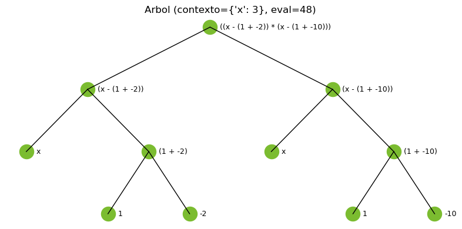

```python
def graficar_arbol_contexto(raiz, context=None, text_dx=0.12, text_dy=0.0, titulo: str = None, color="#4C72B0", imprimir_etiquetas=True, dimensiones=(8, 4)):
    if context is None:
        context = {}
    try:
        eval_value = raiz.eval(context)
        eval_text = f"eval={eval_value}"
    except Exception as e:
        eval_text = f"eval error: {e}"
    titulo_final = titulo or f"Arbol (contexto={context}, {eval_text})"
    graficar_arbol(
        raiz,
        text_dx=text_dx,
        text_dy=text_dy,
        titulo=titulo_final,
        color=color,
        imprimir_etiquetas=imprimir_etiquetas,
        dimensiones=dimensiones,
    )


graficar_arbol_contexto(p7_best_tree, context={"x": 3}, color="#7BBC30")
```

#### Respuestas

##### Análisis algebraico de la expresión encontrada

La expresión generada por el algoritmo de Programación Genética es:

$$ (x - (1 + -2)) \cdot (x - (1 + -10)) $$

##### Simplificación paso a paso

Primero, se simplifican las constantes internas:

$$ 1 + (-2) = -1 \quad \Rightarrow \quad x - (-1) = x + 1 $$

$$ 1 + (-10) = -9 \quad \Rightarrow \quad x - (-9) = x + 9 $$

Por lo tanto, la expresión se reduce a:

$$ (x + 1)(x + 9) $$

Desarrollando el producto:

$$ (x + 1)(x + 9) = x^2 + 10x + 9 $$

##### Comparación con la función objetivo

La función objetivo del problema es:

$$ f(x) = x^2 + 10x + 5 $$

Se observa que la expresión encontrada por GP:

$$ x^2 + 10x + 9 $$

coincide exactamente en los términos cuadrático y lineal, pero presenta una **diferencia constante de +4** respecto de la función objetivo.

##### Interpretación

- El modelo aprendido captura correctamente la **estructura funcional principal** (grado 2 y pendiente).
- El error se debe únicamente al término independiente.
- Dado que se utilizó una penalización por tamaño del árbol, el algoritmo privilegió una expresión **compacta** (11 nodos) frente a una corrección exacta del término constante.

Este comportamiento es consistente con la teoría de **regresión simbólica mediante Programación Genética**, donde la forma global de la función suele aprenderse antes que los ajustes finos.